# Introduction to Statistics for Biosciencies

###### Lecturer **Aldo Felpeto**

###### 11-14 Jan 2021

### **14 Jan - Session 4**

# The Analysis of Variance in the Framework of General Linear Models (GLM)

GLM is a framework for the statistical analysis and inference for the study of linear relationships between a response variable and one or several predictor variables.

GLM is a generalization of simple and multiple linear regression that incorporates categorical variables (factors) and complex designs such as nested,designs, random factors, etc. and inferential techniques such as the analysis of variance.

- Response or dependent var
- Predictor or independent var

Starting point is the sample of individuals with one measurable property - the dependent variable (response).  
The objective is to predict the values of that response property from a linear combination of other (independent) variables.  
* Independent variables can be qualitative (factors) or quantitative (numeric/time).  
* The effect of the variables is always additive.(they cannot interact with other independent variables)

#### Assumptions

- Linear relationship (or linearizable)
- Independence of predictor variables. This can be tested with a correlation matrix or with the VIF (variance inflation factor).
- Independence or no autocorrelation of the values of the response variable
- Normal distribution of residual error
- Homogeneity of variances. The homogeneity has to be between groups of factor levels, it is related with the normality of the errors.

#### Steps

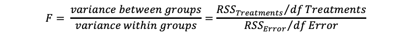

Formula

ANOVA tells us there are differences, but it does not ssay what the differences are for each pair of groups.  
The effects of these pairwise comparisons of factor levels are sometimes called *simple effects*.

|  | Plant | Type | Treatment | conc | uptake |
| --- | --- | --- | --- | --- | --- |
| 1 | Qn1 | Quebec | nonchilled | 95 | 16.0 |
| 2 | Qn1 | Quebec | nonchilled | 175 | 30.4 |
| 3 | Qn1 | Quebec | nonchilled | 250 | 34.8 |
| 4 | Qn1 | Quebec | nonchilled | 350 | 37.2 |
| 5 | Qn1 | Quebec | nonchilled | 500 | 35.3 |
| 6 | Qn1 | Quebec | nonchilled | 675 | 39.2 |

##### Fixed factor vs Random factor

Qualitative variables that: * Fixed factor: contains all the classes in reality, not only on the sample (for example gender is fixed if sample has M/F).  
* Random factor: factor that does not contain all the real classes (levels). For example it includes a few types of plants. These are the plants of the sample, but not all plants in reality.

## Worked Example

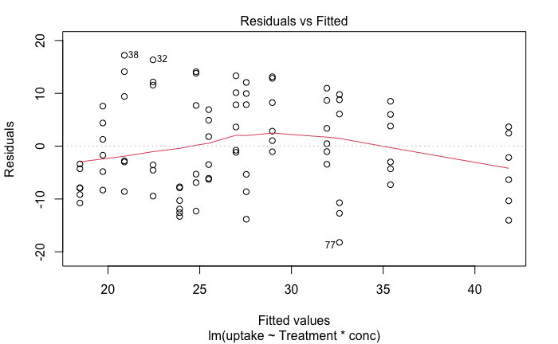

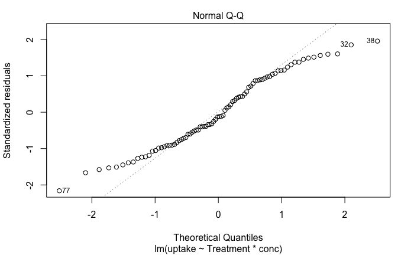

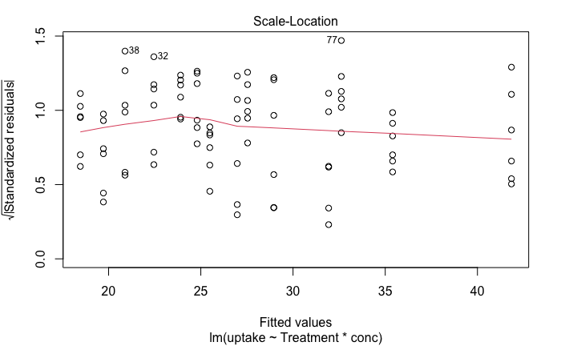

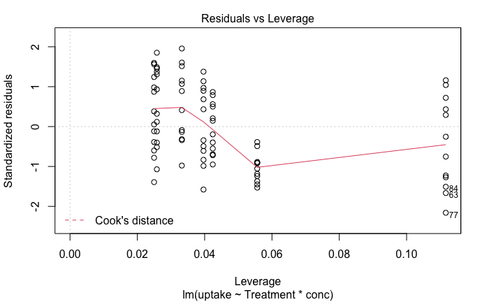

```r
summary(mod1)
```

```
Call:
lm(formula = uptake ~ Treatment * conc, data = CO2)

Residuals:
    Min      1Q  Median      3Q     Max
-18.218  -7.401  -1.117   7.835  17.209

Coefficients:
                       Estimate Std. Error t value Pr(>|t|)
(Intercept)           22.019163   2.464160   8.936 1.17e-13 ***
Treatmentchilled      -5.037747   3.484848  -1.446    0.152
conc                   0.019825   0.004693   4.225 6.29e-05 ***
Treatmentchilled:conc -0.004188   0.006636  -0.631    0.530
---
Signif. codes:  0 ‘***’ 0.001 ‘**’ 0.01 ‘*’ 0.05 ‘.’ 0.1 ‘ ’ 1

Residual standard error: 8.946 on 80 degrees of freedom
Multiple R-squared:  0.3405,    Adjusted R-squared:  0.3157
F-statistic: 13.77 on 3 and 80 DF,  p-value: 2.528e-07
```

```r
require(car)
require(car)
Anova(mod1) #We don't need th interaction
```

```
Anova Table (Type II tests)

Response: uptake
               Sum Sq Df F value    Pr(>F)
Treatment       988.1  1 12.3476 0.0007297 ***
conc           2285.0  1 28.5535 8.377e-07 ***
Treatment:conc   31.9  1  0.3983 0.5297890
Residuals      6402.0 80
---
Signif. codes:  0 ‘***’ 0.001 ‘**’ 0.01 ‘*’ 0.05 ‘.’ 0.1 ‘ ’ 1
```

We check the ANOVA to decide whether to remove non-helpful vars, as these remove degrees of freedom and do not increase the perf. of the model.

Remove interaction.

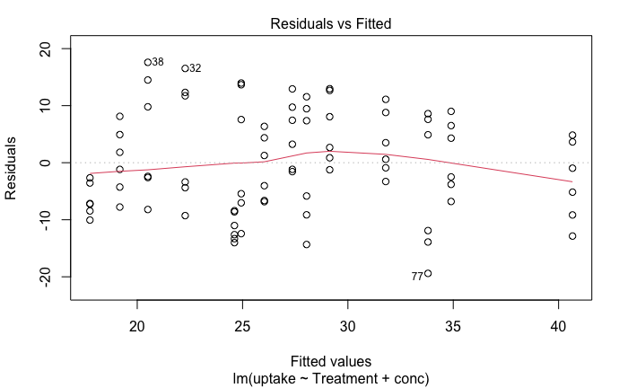

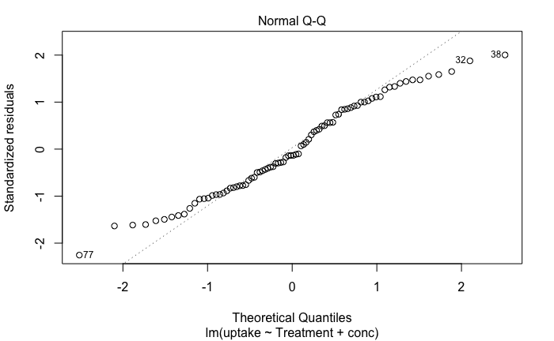

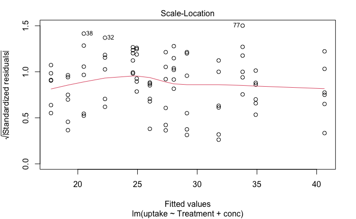

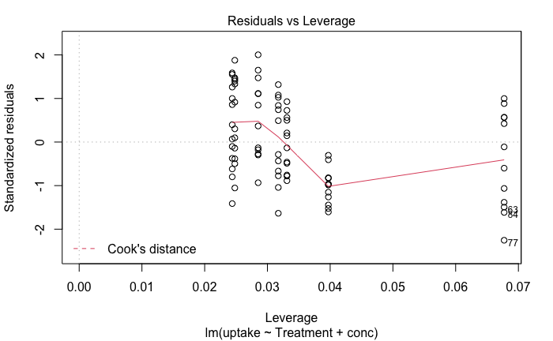

On the plot Residuals vc Fitted, the red line shall be as horizontal as possible , a sign of linear relationship.

Plot Scale-Location is good, as red line nearly flat.

Overall the model looks very good.

```r
summary(mod1.2)
```

```
Call:
lm(formula = uptake ~ Treatment + conc, data = CO2)

Residuals:
    Min      1Q  Median      3Q     Max
-19.401  -7.066  -1.168   7.573  17.597

Coefficients:
                  Estimate Std. Error t value Pr(>|t|)
(Intercept)      22.930052   1.989746  11.524  < 2e-16 ***
Treatmentchilled -6.859524   1.944840  -3.527 0.000695 ***
conc              0.017731   0.003306   5.364 7.55e-07 ***
---
Signif. codes:  0 ‘***’ 0.001 ‘**’ 0.01 ‘*’ 0.05 ‘.’ 0.1 ‘ ’ 1

Residual standard error: 8.912 on 81 degrees of freedom
Multiple R-squared:  0.3372,    Adjusted R-squared:  0.3208
F-statistic:  20.6 on 2 and 81 DF,  p-value: 5.837e-08
```

```r
Anova(mod1.2)
```

```
Anova Table (Type II tests)

Response: uptake
          Sum Sq Df F value    Pr(>F)
Treatment  988.1  1  12.440 0.0006952 ***
conc      2285.0  1  28.767  7.55e-07 ***
Residuals 6433.9 81
---
Signif. codes:  0 ‘***’ 0.001 ‘**’ 0.01 ‘*’ 0.05 ‘.’ 0.1 ‘ ’ 1
```

```r
#Testing ssumptions
vif(mod1.2)
```

```
Treatment      conc
        1         1
```

```r
shapiro.test(residuals(mod1.2))
```

```
    Shapiro-Wilk normality test

data:  residuals(mod1.2)
W = 0.97267, p-value = 0.07073
```

We can assume normallity for the distrib of the residuals.

```r
leveneTest(residuals(mod1.2)~CO2$Treatment)
```

```
Levene's Test for Homogeneity of Variance (center = median)
      Df F value  Pr(>F)
group  1  3.1989 0.07738 .
      82
---
Signif. codes:  0 ‘***’ 0.001 ‘**’ 0.01 ‘*’ 0.05 ‘.’ 0.1 ‘ ’ 1
```

assumptions are met. can proceed without transformation. IN this case the model was done previously.

in this case (because we only have two levels) we don’t need pos-hoc tests because we know already that the two treatments are different.

But here we do it because normally we nee to do.

```r
summary(glht(mod1.2,linfct=mcp(Treatment="Tukey")))
```

```
     Simultaneous Tests for General Linear Hypotheses

Multiple Comparisons of Means: Tukey Contrasts


Fit: lm(formula = uptake ~ Treatment + conc, data = CO2)

Linear Hypotheses:
                          Estimate Std. Error t value Pr(>|t|)
chilled - nonchilled == 0   -6.860      1.945  -3.527 0.000695 ***
---
Signif. codes:  0 ‘***’ 0.001 ‘**’ 0.01 ‘*’ 0.05 ‘.’ 0.1 ‘ ’ 1
(Adjusted p values reported -- single-step method)
```

#### Adding Random Factors

```r
#Adding random factors
require(lme4)
#Adding random factors
require(lme4)
mod2<-lmer(uptake~Treatment+conc+(1|Type),data=CO2) #The Ecotype affecting the intercept
```

```r
#Final model fit and Analysis of Deviance
summary(mod2)
```

```
Linear mixed model fit by REML ['lmerMod']
Formula: uptake ~ Treatment + conc + (1 | Type)
   Data: CO2

REML criterion at convergence: 553

Scaled residuals:
    Min      1Q  Median      3Q     Max
-2.7889 -0.4661  0.1777  0.6563  1.8310

Random effects:
 Groups   Name        Variance Std.Dev.
 Type     (Intercept) 79.22    8.900
 Residual             38.35    6.193
Number of obs: 84, groups:  Type, 2

Fixed effects:
                  Estimate Std. Error t value
(Intercept)      22.930052   6.443679   3.559
Treatmentchilled -6.859524   1.351439  -5.076
conc              0.017731   0.002297   7.719

Correlation of Fixed Effects:
            (Intr) Trtmnt
Trtmntchlld -0.105
conc        -0.155  0.000
```

```r
Anova(mod2)
```

```
Analysis of Deviance Table (Type II Wald chisquare tests)

Response: uptake
           Chisq Df Pr(>Chisq)
Treatment 25.763  1  3.860e-07 ***
conc      59.576  1  1.177e-14 ***
---
Signif. codes:  0 ‘***’ 0.001 ‘**’ 0.01 ‘*’ 0.05 ‘.’ 0.1 ‘ ’ 1
```

#### Adding Random Factors

**Fixed factor:** includes all the variability that this factor can include. This happens when all factor levels that exist in nature are present in our sample. **Random factor:** does not include all the possible variability, only some. Typical random factors: locations from different regions. As these do not include all locations or Earth. Other examples are: Individuals; each individual fish would be a random factor. Since we measure each fish several times, there will be auto-correlation. Take into account auto-correlation of data.  
We don’t test hypothesis in random factors. we don’t test for differences on random factors. (so no p value).  
We pay attention to random factors because they cause auto-correlation.

The ‘+’ means that factors are additive, meaning that they do not interact among them.  
The ‘|’ means which part of the model is being affected by the random factor (on the left)  
The ‘1’ is the intercept.

This data set shows a *nested* or *hierarchical* design

The ‘/’ means the nested of the vars. in this case *plant* is nested in *type*

Which model is better?

|  | df | AIC |
| --- | --- | --- |
| mod1.2 | 4 | 610.8169 |
| mod2 | 5 | 563.0128 |
| mod3 | 6 | 564.1076 |

- df reflects the complexity of each model; lowest simpler (better).
- AIC, the lower the better????  
  Obvious choice is model 2.  
  By including one more parameter model 3 is not better enough than model 2 to justify the inclusion of the new parameter.

```r
summary(mod2)
```

```
Linear mixed model fit by REML ['lmerMod']
Formula: uptake ~ Treatment + conc + (1 | Type)
   Data: CO2

REML criterion at convergence: 553

Scaled residuals:
    Min      1Q  Median      3Q     Max
-2.7889 -0.4661  0.1777  0.6563  1.8310

Random effects:
 Groups   Name        Variance Std.Dev.
 Type     (Intercept) 79.22    8.900
 Residual             38.35    6.193
Number of obs: 84, groups:  Type, 2

Fixed effects:
                  Estimate Std. Error t value
(Intercept)      22.930052   6.443679   3.559
Treatmentchilled -6.859524   1.351439  -5.076
conc              0.017731   0.002297   7.719

Correlation of Fixed Effects:
            (Intr) Trtmnt
Trtmntchlld -0.105
conc        -0.155  0.000
```

```r
Anova(mod2)
```

[output not shown]

Deviance - not sum of squares- rather the *likelihood* (inverse of probability) of of the parameters of bneing significant in the model.  
The concentration (var “conc”) contributes more to explain the model twice as much as the var “treatment”.  
Deviance is the likelihood that a var influences the model.

# EXERCISES

## 1

With the data set “Cholesterol.csv”, perform a linear model with analysis of variance using the cholesterol in blood as dependent variable, Gender and Physical condition as independent categorical factors, and Age as covariate. Test the assumptions and formulate the model first considering the interactions and removing them if not significant.

|  | X | Chol.Blood | Age | Gender | Physical.condition | Hospital | District |
| --- | --- | --- | --- | --- | --- | --- | --- |
| 1 | 1 | 214.8251 | 57 | M | A | H1 | Porto |
| 2 | 2 | 203.5490 | 45 | F | A | H1 | Porto |
| 3 | 3 | 221.5127 | 68 | F | A | H1 | Porto |
| 4 | 4 | 195.1060 | 43 | F | A | H1 | Porto |
| 5 | 5 | 193.9155 | 36 | F | A | H1 | Porto |
| 6 | 6 | 200.1424 | 34 | F | A | H1 | Porto |

```r
str(data)
```

```
'data.frame':   720 obs. of  7 variables:
 $ X                 : int  1 2 3 4 5 6 7 8 9 10 ...
 $ Chol.Blood        : num  215 204 222 195 194 ...
 $ Age               : int  57 45 68 43 36 34 56 40 50 37 ...
 $ Gender            : Factor w/ 2 levels "F","M": 2 1 1 1 1 1 2 1 1 2 ...
 $ Physical.condition: Factor w/ 4 levels "A","B","C","D": 1 1 1 1 1 1 1 1 1 1 ...
 $ Hospital          : Factor w/ 12 levels "H1","H10","H11",..: 1 1 1 1 1 1 1 1 1 1 ...
 $ District          : Factor w/ 3 levels "Aveiro","Braga",..: 3 3 3 3 3 3 3 3 3 3 ...
```

```r
model <- lm(datta = data, Chol.Blood~Gender)
```

```
Error in eval(predvars, data, env) : object 'Chol.Blood' not found
```

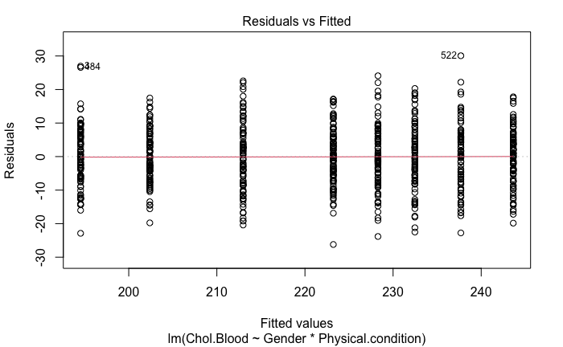

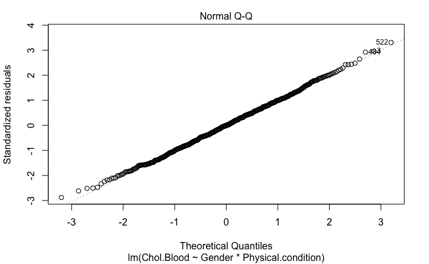

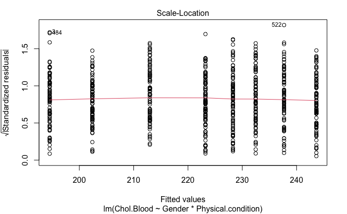

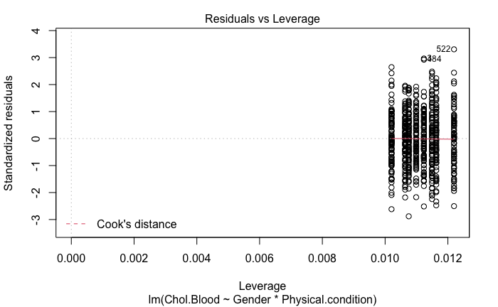

Var Hospital is neted in var Districts

## 2

Consider adding random factors to the model from those other variables present in the data set. Select the best model by AIC.